# kv2154_Assignment3_Problem1

Solution 1.1):

Co-adaptation refers to the phenomenon in deep learning where multiple components of a model become highly dependent on each other to achieve good performance, to the point where it becomes difficult to isolate the contributions of individual components. This can lead to overfitting and poor generalization when the model is applied to new data.

In deep learning, a model typically consists of many layers, each of which contains a large number of learnable parameters. These parameters are updated during training to optimize the model's performance on a training set. However, because the layers are highly interconnected, the optimization process can result in some layers becoming dependent on the output of others. This dependency can lead to a situation where the performance of the entire model is heavily dependent on the behavior of a few key components.

Internal covariance-shift, on the other hand, refers to a problem that can arise in machine learning algorithms when the statistical distribution of the input data changes between training and testing. This can happen, for example, if the training data is drawn from one population or environment, and the testing data is drawn from a different population or environment.

The problem with internal covariance-shift is that the model may not be able to generalize well to the testing data, because the statistical patterns that it learned from the training data no longer hold. This can lead to poor performance and low accuracy.

One way to mitigate the effects of internal covariance-shift is to use techniques such as domain adaptation or transfer learning, which aim to adapt the model to the new testing data by adjusting its internal representations or learning new representations from a related task. These techniques can help the model to generalize better to new environments and improve its accuracy.

```
Epoch [1/10], Step [100/938], Loss: 0.2941
Epoch [1/10], Step [200/938], Loss: 0.0614
Epoch [1/10], Step [300/938], Loss: 0.0811
Epoch [1/10], Step [400/938], Loss: 0.2154
Epoch [1/10], Step [500/938], Loss: 0.1622
Epoch [1/10], Step [600/938], Loss: 0.0694
Epoch [1/10], Step [700/938], Loss: 0.0488
Epoch [1/10], Step [800/938], Loss: 0.2468
Epoch [1/10], Step [900/938], Loss: 0.0083
Epoch [1/10], Train Loss: 0.1607, Train Acc: 96.18, Test Loss: 0.0723, Test Acc: 97.76
Epoch [2/10], Step [100/938], Loss: 0.0553
Epoch [2/10], Step [200/938], Loss: 0.0417
Epoch [2/10], Step [300/938], Loss: 0.0132
Epoch [2/10], Step [400/938], Loss: 0.0263
Epoch [2/10], Step [500/938], Loss: 0.0233
Epoch [2/10], Step [600/938], Loss: 0.0176
Epoch [2/10], Step [700/938], Loss: 0.0196
Epoch [2/10], Step [800/938], Loss: 0.0874
Epoch [2/10], Step [900/938], Loss: 0.0115
Epoch [2/10], Train Loss: 0.0467, Train Acc: 98.60, Test Loss: 0.0414, Test Acc: 98.72
Epoch [3/10], Step [100/938], Loss: 0.0031
Epoch [3/10], Step [200/938], Loss: 0.0406
Epoch [3/10], Step [300/938], Loss: 0.0283
Epoch [3/10], Step [400/938], Loss: 0.1055
Epoch [3/10], Step [500/938], Loss: 0.0666
Epoch [3/10], Step [600/938], Loss: 0.0175
Epoch [3/10], Step [700/938], Loss: 0.0096
Epoch [3/10], Step [800/938], Loss: 0.0414
Epoch [3/10], Step [900/938], Loss: 0.0332
Epoch [3/10], Train Loss: 0.0365, Train Acc: 98.89, Test Loss: 0.0408, Test Acc: 98.69
Epoch [4/10], Step [100/938], Loss: 0.0264
Epoch [4/10], Step [200/938], Loss: 0.0016
Epoch [4/10], Step [300/938], Loss: 0.0021
Epoch [4/10], Step [400/938], Loss: 0.0271
Epoch [4/10], Step [500/938], Loss: 0.0073
Epoch [4/10], Step [600/938], Loss: 0.0045
Epoch [4/10], Step [700/938], Loss: 0.0188
Epoch [4/10], Step [800/938], Loss: 0.0101
Epoch [4/10], Step [900/938], Loss: 0.0118
Epoch [4/10], Train Loss: 0.0283, Train Acc: 99.13, Test Loss: 0.0324, Test Acc: 98.92
```

[output cut: 45 more lines]

```
Epoch [9/10], Step [600/938], Loss: 0.0351
Epoch [9/10], Step [700/938], Loss: 0.0014
Epoch [9/10], Step [800/938], Loss: 0.0042
Epoch [9/10], Step [900/938], Loss: 0.0138
Epoch [9/10], Train Loss: 0.0145, Train Acc: 99.56, Test Loss: 0.0135, Test Acc: 99.49
Epoch [10/10], Step [100/938], Loss: 0.0005
Epoch [10/10], Step [200/938], Loss: 0.0053
Epoch [10/10], Step [300/938], Loss: 0.0290
Epoch [10/10], Step [400/938], Loss: 0.0130
Epoch [10/10], Step [500/938], Loss: 0.0003
Epoch [10/10], Step [600/938], Loss: 0.0009
Epoch [10/10], Step [700/938], Loss: 0.0013
Epoch [10/10], Step [800/938], Loss: 0.0015
Epoch [10/10], Step [900/938], Loss: 0.0050
Epoch [10/10], Train Loss: 0.0145, Train Acc: 99.53, Test Loss: 0.0228, Test Acc: 99.29
```

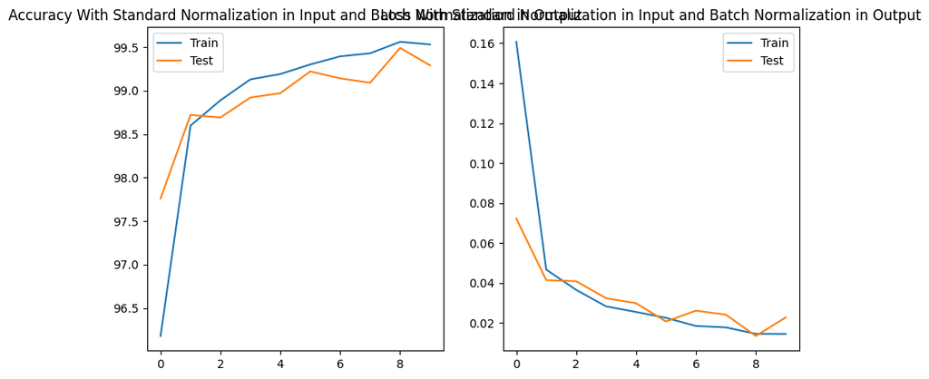

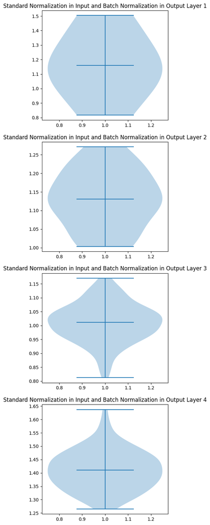

```python
#Solution 1.2):

import torch
import torch.nn as nn
import torch.optim as optim
import torchvision.datasets as datasets
import torchvision.transforms as transforms
import numpy as np
import matplotlib.pyplot as plt

# Load the MNIST dataset
train_dataset = datasets.MNIST(root='./data', train=True, transform=transforms.Compose([
                                    transforms.ToTensor(),
                                    transforms.Normalize((0.131,), (0.302,))
                                ]), download=True)
test_dataset = datasets.MNIST(root='./data', train=False, transform=transforms.Compose([
                                    transforms.ToTensor(),
                                    transforms.Normalize((0.131,), (0.302,))
                                ]), download=True)

# Define the data loaders
batch_size = 64
train_loader = torch.utils.data.DataLoader(train_dataset, batch_size=batch_size, shuffle=True)
test_loader = torch.utils.data.DataLoader(test_dataset, batch_size=batch_size, shuffle=False)

# Define the LeNet-5 model with batch normalization for all layers
class LeNet5(nn.Module):
    def __init__(self):
        super(LeNet5, self).__init__()
        self.conv1 = nn.Conv2d(1, 6, kernel_size=5)
        self.bn1 = nn.BatchNorm2d(6)
        self.conv2 = nn.Conv2d(6, 16, kernel_size=5)
        self.bn2 = nn.BatchNorm2d(16)
        self.fc1 = nn.Linear(16*4*4, 120)
        self.bn3 = nn.BatchNorm1d(120)
        self.fc2 = nn.Linear(120, 84)
        self.bn4 = nn.BatchNorm1d(84)
        self.fc3 = nn.Linear(84, 10)
        self.relu = nn.ReLU()
        self.maxpool = nn.MaxPool2d(kernel_size=2, stride=2)

    def forward(self, x):
        x = self.bn1(self.conv1(x))
        x = self.relu(x)
        x = self.maxpool(x)
        x = self.bn2(self.conv2(x))
        x = self.relu(x)
        x = self.maxpool(x)
        x = x.view(-1, 16*4*4)
        x = self.bn3(self.fc1(x))
        x = self.relu(x)
        x = self.bn4(self.fc2(x))
        x = self.relu(x)
        x = self.fc3(x)
        return x

# Initialize the model
model = LeNet5()

# Define the loss function and optimizer
criterion = nn.CrossEntropyLoss()
optimizer = optim.Adam(model.parameters(), lr=0.001)

# Define the batch size and number of epochs
batch_size = 64
n_epochs = 10

# Create data loaders for the train and test datasets
train_loader = torch.utils.data.DataLoader(train_dataset, batch_size=batch_size, shuffle=True)
test_loader = torch.utils.data.DataLoader(test_dataset, batch_size=batch_size, shuffle=False)

# Train the model
train_loss_bn = []
train_acc_bn = []
test_loss_bn = []
test_acc_bn = []

for epoch in range(n_epochs):
    model.train()
    train_loss = 0.0
    train_total = 0
    train_correct = 0
    for i, (inputs, labels) in enumerate(train_loader):
        optimizer.zero_grad()
        outputs = model(inputs)
        loss = criterion(outputs, labels)
        loss.backward()
        optimizer.step()
        train_loss += loss.item() * inputs.size(0)
        _, predicted = torch.max(outputs.data, 1)
        train_total += labels.size(0)
        train_correct += (predicted == labels).sum().item()

        # Print training statistics
        if (i+1) % 100 == 0:
            print('Epoch [{}/{}], Step [{}/{}], Loss: {:.4f}'.format(epoch+1, n_epochs, i+1, len(train_loader), loss.item()))

    train_loss /= len(train_loader.dataset)
    train_acc = 100 * train_correct / train_total
    train_loss_bn.append(train_loss)
    train_acc_bn.append(train_acc)

    model.eval()
    test_loss = 0.0
    test_total = 0
    test_correct = 0
    for i, (inputs, labels) in enumerate(test_loader):
        optimizer.zero_grad()
        outputs = model(inputs)
        loss = criterion(outputs, labels)
        loss.backward()
        optimizer.step()
        test_loss += loss.item() * inputs.size(0)
        _, predicted = torch.max(outputs.data, 1)
        test_total += labels.size(0)
        test_correct += (predicted == labels).sum().item()

    test_loss /= len(test_loader.dataset)
    test_acc = 100 * test_correct / test_total
    test_loss_bn.append(test_loss)
    test_acc_bn.append(test_acc)

    print('Epoch [{}/{}], Train Loss: {:.4f}, Train Acc: {:.2f}, Test Loss: {:.4f}, Test Acc: {:.2f}'.format(epoch+1, n_epochs, train_loss, train_acc, test_loss, test_acc))

plt.figure(figsize=(10, 5))
plt.subplot(1, 2, 1)
plt.plot(train_acc_bn, label='Train')
plt.plot(test_acc_bn, label='Test')
plt.title('Accuracy With Standard Normalization in Input and Batch Normalization in Output')
plt.legend()
plt.subplot(1, 2, 2)
plt.plot(train_loss_bn, label='Train')
plt.plot(test_loss_bn, label='Test')
plt.title('Loss With Standard Normalization in Input and Batch Normalization in Output')
plt.legend()
plt.show()

bn_params = []
for name, module in model.named_modules():
    if isinstance(module, nn.BatchNorm2d) or isinstance(module, nn.BatchNorm1d):
        bn_params.append(module.weight.data.cpu().numpy())

fig, axs = plt.subplots(len(bn_params), figsize=(5, 20))
for i, p in enumerate(bn_params):
    axs[i].violinplot(dataset=p, showmeans=True)
    axs[i].set_title(f'Standard Normalization in Input and Batch Normalization in Output Layer {i+1}')
plt.show()
```

```
Epoch [1/10], Step [100/938], Loss: 0.3049
Epoch [1/10], Step [200/938], Loss: 0.2731
Epoch [1/10], Step [300/938], Loss: 0.0550
Epoch [1/10], Step [400/938], Loss: 0.0842
Epoch [1/10], Step [500/938], Loss: 0.0500
Epoch [1/10], Step [600/938], Loss: 0.0676
Epoch [1/10], Step [700/938], Loss: 0.0552
Epoch [1/10], Step [800/938], Loss: 0.0773
Epoch [1/10], Step [900/938], Loss: 0.0472
Epoch [1/10], Train Loss: 0.1659, Train Acc: 95.99, Test Loss: 0.0763, Test Acc: 97.49
Epoch [2/10], Step [100/938], Loss: 0.0335
Epoch [2/10], Step [200/938], Loss: 0.0354
Epoch [2/10], Step [300/938], Loss: 0.1013
Epoch [2/10], Step [400/938], Loss: 0.0679
Epoch [2/10], Step [500/938], Loss: 0.1258
Epoch [2/10], Step [600/938], Loss: 0.0113
Epoch [2/10], Step [700/938], Loss: 0.0941
Epoch [2/10], Step [800/938], Loss: 0.0423
Epoch [2/10], Step [900/938], Loss: 0.0226
Epoch [2/10], Train Loss: 0.0504, Train Acc: 98.48, Test Loss: 0.0426, Test Acc: 98.66
Epoch [3/10], Step [100/938], Loss: 0.0018
Epoch [3/10], Step [200/938], Loss: 0.1074
Epoch [3/10], Step [300/938], Loss: 0.0893
Epoch [3/10], Step [400/938], Loss: 0.0158
Epoch [3/10], Step [500/938], Loss: 0.0123
Epoch [3/10], Step [600/938], Loss: 0.0143
Epoch [3/10], Step [700/938], Loss: 0.0180
Epoch [3/10], Step [800/938], Loss: 0.0126
Epoch [3/10], Step [900/938], Loss: 0.0770
Epoch [3/10], Train Loss: 0.0369, Train Acc: 98.85, Test Loss: 0.0361, Test Acc: 98.88
Epoch [4/10], Step [100/938], Loss: 0.0076
Epoch [4/10], Step [200/938], Loss: 0.0528
Epoch [4/10], Step [300/938], Loss: 0.0206
Epoch [4/10], Step [400/938], Loss: 0.0393
Epoch [4/10], Step [500/938], Loss: 0.0433
Epoch [4/10], Step [600/938], Loss: 0.0172
Epoch [4/10], Step [700/938], Loss: 0.0065
Epoch [4/10], Step [800/938], Loss: 0.0089
Epoch [4/10], Step [900/938], Loss: 0.0316
Epoch [4/10], Train Loss: 0.0299, Train Acc: 99.05, Test Loss: 0.0460, Test Acc: 98.59
```

[output cut: 45 more lines]

```
Epoch [9/10], Step [600/938], Loss: 0.0184
Epoch [9/10], Step [700/938], Loss: 0.0035
Epoch [9/10], Step [800/938], Loss: 0.0016
Epoch [9/10], Step [900/938], Loss: 0.0552
Epoch [9/10], Train Loss: 0.0181, Train Acc: 99.38, Test Loss: 0.0201, Test Acc: 99.36
Epoch [10/10], Step [100/938], Loss: 0.0005
Epoch [10/10], Step [200/938], Loss: 0.0011
Epoch [10/10], Step [300/938], Loss: 0.0054
Epoch [10/10], Step [400/938], Loss: 0.0445
Epoch [10/10], Step [500/938], Loss: 0.0022
Epoch [10/10], Step [600/938], Loss: 0.0043
Epoch [10/10], Step [700/938], Loss: 0.0094
Epoch [10/10], Step [800/938], Loss: 0.0021
Epoch [10/10], Step [900/938], Loss: 0.0012
Epoch [10/10], Train Loss: 0.0143, Train Acc: 99.56, Test Loss: 0.0227, Test Acc: 99.17
```

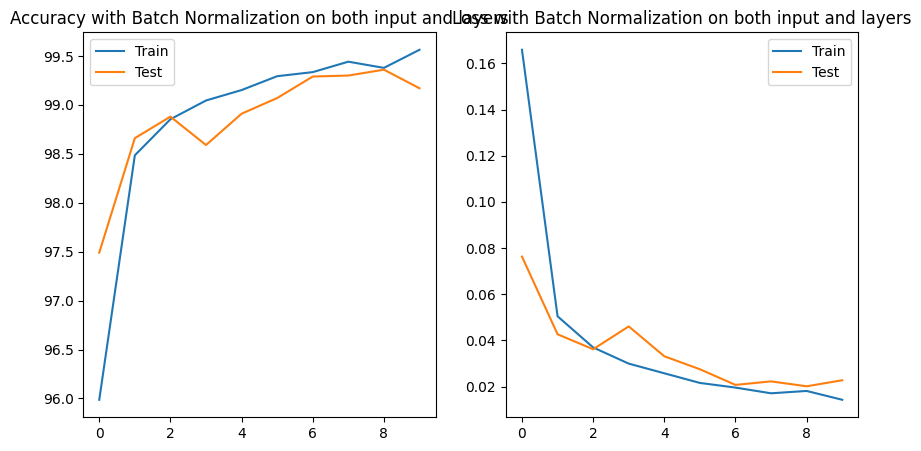

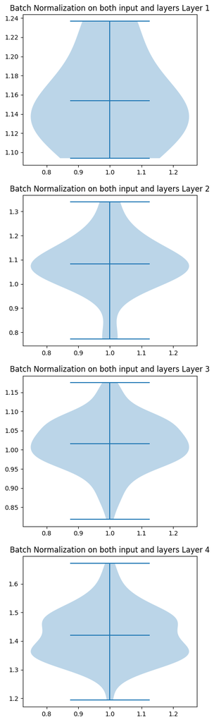

```python
#Solution 1.3):

import torch
import torch.nn as nn
import torch.optim as optim
import torchvision.datasets as datasets
import torchvision.transforms as transforms
import numpy as np
import matplotlib.pyplot as plt

# Load the MNIST dataset
train_dataset = datasets.MNIST(root='./data', train=True, transform=transforms.ToTensor(), download=True)
test_dataset = datasets.MNIST(root='./data', train=False, transform=transforms.ToTensor())

# Define the LeNet-5 model with batch normalization for all layers
class LeNet5(nn.Module):
    def __init__(self):
        super(LeNet5, self).__init__()
        self.conv1 = nn.Conv2d(1, 6, kernel_size=5)
        self.bn1 = nn.BatchNorm2d(6)
        self.conv2 = nn.Conv2d(6, 16, kernel_size=5)
        self.bn2 = nn.BatchNorm2d(16)
        self.fc1 = nn.Linear(16*4*4, 120)
        self.bn3 = nn.BatchNorm1d(120)
        self.fc2 = nn.Linear(120, 84)
        self.bn4 = nn.BatchNorm1d(84)
        self.fc3 = nn.Linear(84, 10)
        self.relu = nn.ReLU()
        self.maxpool = nn.MaxPool2d(kernel_size=2, stride=2)

    def forward(self, x):
        x = self.bn1(self.conv1(x))
        x = self.relu(x)
        x = self.maxpool(x)
        x = self.bn2(self.conv2(x))
        x = self.relu(x)
        x = self.maxpool(x)
        x = x.view(-1, 16*4*4)
        x = self.bn3(self.fc1(x))
        x = self.relu(x)
        x = self.bn4(self.fc2(x))
        x = self.relu(x)
        x = self.fc3(x)
        return x

# Initialize the model
model = LeNet5()

# Define the loss function and optimizer
criterion = nn.CrossEntropyLoss()
optimizer = optim.Adam(model.parameters(), lr=0.001)

# Define the batch size and number of epochs
batch_size = 64
n_epochs = 10

# Create data loaders for the train and test datasets
train_loader = torch.utils.data.DataLoader(train_dataset, batch_size=batch_size, shuffle=True)
test_loader = torch.utils.data.DataLoader(test_dataset, batch_size=batch_size, shuffle=False)

# Train the model
train_loss_bn = []
train_acc_bn = []
test_loss_bn = []
test_acc_bn = []

for epoch in range(n_epochs):
    model.train()
    train_loss = 0.0
    train_total = 0
    train_correct = 0
    for i, (inputs, labels) in enumerate(train_loader):
        optimizer.zero_grad()
        outputs = model(inputs)
        loss = criterion(outputs, labels)
        loss.backward()
        optimizer.step()
        train_loss += loss.item() * inputs.size(0)
        _, predicted = torch.max(outputs.data, 1)
        train_total += labels.size(0)
        train_correct += (predicted == labels).sum().item()

        # Print training statistics
        if (i+1) % 100 == 0:
            print('Epoch [{}/{}], Step [{}/{}], Loss: {:.4f}'.format(epoch+1, n_epochs, i+1, len(train_loader), loss.item()))

    train_loss /= len(train_loader.dataset)
    train_acc = 100 * train_correct / train_total
    train_loss_bn.append(train_loss)
    train_acc_bn.append(train_acc)

    model.eval()
    test_loss = 0.0
    test_total = 0
    test_correct = 0
    for i, (inputs, labels) in enumerate(test_loader):
        optimizer.zero_grad()
        outputs = model(inputs)
        loss = criterion(outputs, labels)
        loss.backward()
        optimizer.step()
        test_loss += loss.item() * inputs.size(0)
        _, predicted = torch.max(outputs.data, 1)
        test_total += labels.size(0)
        test_correct += (predicted == labels).sum().item()

    test_loss /= len(test_loader.dataset)
    test_acc = 100 * test_correct / test_total
    test_loss_bn.append(test_loss)
    test_acc_bn.append(test_acc)

    print('Epoch [{}/{}], Train Loss: {:.4f}, Train Acc: {:.2f}, Test Loss: {:.4f}, Test Acc: {:.2f}'.format(epoch+1, n_epochs, train_loss, train_acc, test_loss, test_acc))

plt.figure(figsize=(10, 5))
plt.subplot(1, 2, 1)
plt.plot(train_acc_bn, label='Train')
plt.plot(test_acc_bn, label='Test')
plt.title('Accuracy with Batch Normalization on both input and layers')
plt.legend()
plt.subplot(1, 2, 2)
plt.plot(train_loss_bn, label='Train')
plt.plot(test_loss_bn, label='Test')
plt.title('Loss with Batch Normalization on both input and layers')
plt.legend()
plt.show()

bn_params = []
for name, module in model.named_modules():
    if isinstance(module, nn.BatchNorm2d) or isinstance(module, nn.BatchNorm1d):
        bn_params.append(module.weight.data.cpu().numpy())

fig, axs = plt.subplots(len(bn_params), figsize=(5, 20))
for i, p in enumerate(bn_params):
    axs[i].violinplot(dataset=p, showmeans=True)
    axs[i].set_title(f'Batch Normalization on both input and layers Layer {i+1}')
plt.show()
```

```
Epoch [1/10], Step [100/938], Loss: 0.7948
Epoch [1/10], Step [200/938], Loss: 0.4855
Epoch [1/10], Step [300/938], Loss: 0.1772
Epoch [1/10], Step [400/938], Loss: 0.2756
Epoch [1/10], Step [500/938], Loss: 0.0792
Epoch [1/10], Step [600/938], Loss: 0.1046
Epoch [1/10], Step [700/938], Loss: 0.2825
Epoch [1/10], Step [800/938], Loss: 0.0977
Epoch [1/10], Step [900/938], Loss: 0.1902
Epoch [1/10], Train Loss: 0.3818, Train Acc: 88.17, Test Loss: 0.0831, Test Acc: 97.24
Epoch [2/10], Step [100/938], Loss: 0.1191
Epoch [2/10], Step [200/938], Loss: 0.0554
Epoch [2/10], Step [300/938], Loss: 0.1783
Epoch [2/10], Step [400/938], Loss: 0.0300
Epoch [2/10], Step [500/938], Loss: 0.1074
Epoch [2/10], Step [600/938], Loss: 0.0890
Epoch [2/10], Step [700/938], Loss: 0.0720
Epoch [2/10], Step [800/938], Loss: 0.0665
Epoch [2/10], Step [900/938], Loss: 0.0707
Epoch [2/10], Train Loss: 0.1191, Train Acc: 96.64, Test Loss: 0.0502, Test Acc: 98.58
Epoch [3/10], Step [100/938], Loss: 0.1632
Epoch [3/10], Step [200/938], Loss: 0.2067
Epoch [3/10], Step [300/938], Loss: 0.0597
Epoch [3/10], Step [400/938], Loss: 0.0557
Epoch [3/10], Step [500/938], Loss: 0.0580
Epoch [3/10], Step [600/938], Loss: 0.0668
Epoch [3/10], Step [700/938], Loss: 0.0263
Epoch [3/10], Step [800/938], Loss: 0.1739
Epoch [3/10], Step [900/938], Loss: 0.0503
Epoch [3/10], Train Loss: 0.0860, Train Acc: 97.55, Test Loss: 0.0377, Test Acc: 98.84
Epoch [4/10], Step [100/938], Loss: 0.0473
Epoch [4/10], Step [200/938], Loss: 0.0680
Epoch [4/10], Step [300/938], Loss: 0.1888
Epoch [4/10], Step [400/938], Loss: 0.0284
Epoch [4/10], Step [500/938], Loss: 0.0325
Epoch [4/10], Step [600/938], Loss: 0.0340
Epoch [4/10], Step [700/938], Loss: 0.0809
Epoch [4/10], Step [800/938], Loss: 0.0621
Epoch [4/10], Step [900/938], Loss: 0.0681
Epoch [4/10], Train Loss: 0.0716, Train Acc: 98.07, Test Loss: 0.0312, Test Acc: 99.10
```

[output cut: 45 more lines]

```
Epoch [9/10], Step [600/938], Loss: 0.0210
Epoch [9/10], Step [700/938], Loss: 0.0756
Epoch [9/10], Step [800/938], Loss: 0.0059
Epoch [9/10], Step [900/938], Loss: 0.0035
Epoch [9/10], Train Loss: 0.0392, Train Acc: 98.90, Test Loss: 0.0134, Test Acc: 99.55
Epoch [10/10], Step [100/938], Loss: 0.0305
Epoch [10/10], Step [200/938], Loss: 0.1178
Epoch [10/10], Step [300/938], Loss: 0.0148
Epoch [10/10], Step [400/938], Loss: 0.0070
Epoch [10/10], Step [500/938], Loss: 0.0105
Epoch [10/10], Step [600/938], Loss: 0.0290
Epoch [10/10], Step [700/938], Loss: 0.1500
Epoch [10/10], Step [800/938], Loss: 0.0116
Epoch [10/10], Step [900/938], Loss: 0.0887
Epoch [10/10], Train Loss: 0.0369, Train Acc: 98.92, Test Loss: 0.0134, Test Acc: 99.56
```

[output not shown]

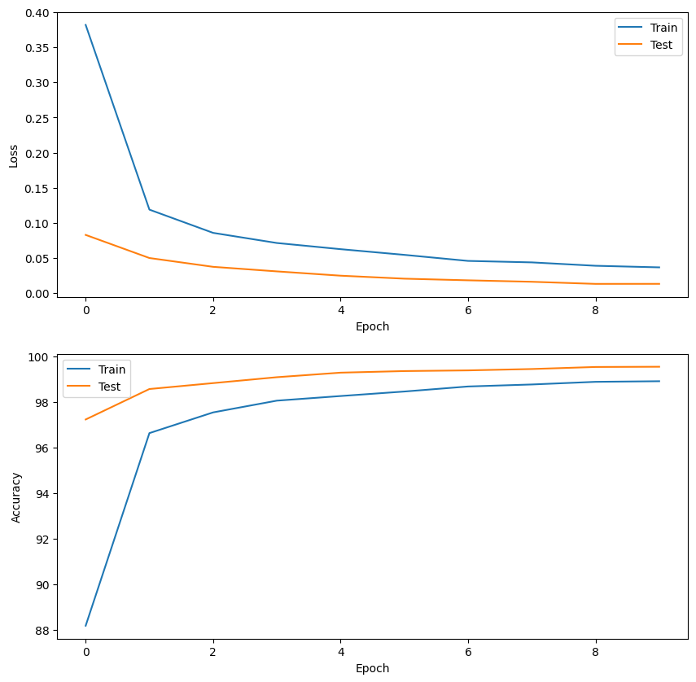

[figure not shown]

```python
#Solution 1.4):

#Drop out

import torch
import torch.nn as nn
import torch.optim as optim
import torchvision.datasets as datasets
import torchvision.transforms as transforms
import numpy as np
import matplotlib.pyplot as plt

# Load the MNIST dataset
train_dataset = datasets.MNIST(root='./data', train=True, transform=transforms.ToTensor(), download=True)
test_dataset = datasets.MNIST(root='./data', train=False, transform=transforms.ToTensor())

# Define the LeNet-5 model with dropout for all layers
class LeNet5(nn.Module):
    def __init__(self):
        super(LeNet5, self).__init__()
        self.conv1 = nn.Conv2d(1, 6, kernel_size=5)
        self.conv2 = nn.Conv2d(6, 16, kernel_size=5)
        self.fc1 = nn.Linear(16*4*4, 120)
        self.dropout1 = nn.Dropout(p=0.2)
        self.fc2 = nn.Linear(120, 84)
        self.dropout2 = nn.Dropout(p=0.5)
        self.fc3 = nn.Linear(84, 10)
        self.relu = nn.ReLU()
        self.maxpool = nn.MaxPool2d(kernel_size=2, stride=2)

    def forward(self, x):
        x = self.conv1(x)
        x = self.relu(x)
        x = self.maxpool(x)
        x = self.conv2(x)
        x = self.relu(x)
        x = self.maxpool(x)
        x = x.view(-1, 16*4*4)
        x = self.fc1(x)
        x = self.relu(x)
        x = self.dropout1(x)
        x = self.fc2(x)
        x = self.relu(x)
        x = self.dropout2(x)
        x = self.fc3(x)
        return x

# Initialize the model
model = LeNet5()

# Define the loss function and optimizer
criterion = nn.CrossEntropyLoss()
optimizer = optim.Adam(model.parameters())

# Define the batch size and number of epochs
batch_size = 64
n_epochs = 10

# Create data loaders for the train and test datasets
train_loader = torch.utils.data.DataLoader(train_dataset, batch_size=batch_size, shuffle=True)
test_loader = torch.utils.data.DataLoader(test_dataset, batch_size=batch_size, shuffle=False)

# Train the model
train_loss_bn = []
train_acc_bn = []
test_loss_bn = []
test_acc_bn = []

for epoch in range(n_epochs):
    model.train()
    train_loss = 0.0
    train_total = 0
    train_correct = 0
    for i, (inputs, labels) in enumerate(train_loader):
        optimizer.zero_grad()
        outputs = model(inputs)
        loss = criterion(outputs, labels)
        loss.backward()
        optimizer.step()
        train_loss += loss.item() * inputs.size(0)
        _, predicted = torch.max(outputs.data, 1)
        train_total += labels.size(0)
        train_correct += (predicted == labels).sum().item()

        # Print training statistics
        if (i+1) % 100 == 0:
            print('Epoch [{}/{}], Step [{}/{}], Loss: {:.4f}'.format(epoch+1, n_epochs, i+1, len(train_loader), loss.item()))

    train_loss /= len(train_loader.dataset)
    train_acc = 100 * train_correct / train_total
    train_loss_bn.append(train_loss)
    train_acc_bn.append(train_acc)

    model.eval()
    test_loss = 0.0
    test_total = 0
    test_correct = 0
    for i, (inputs, labels) in enumerate(test_loader):
        optimizer.zero_grad()
        outputs = model(inputs)
        loss = criterion(outputs, labels)
        loss.backward()
        optimizer.step()
        test_loss += loss.item() * inputs.size(0)
        _, predicted = torch.max(outputs.data, 1)
        test_total += labels.size(0)
        test_correct += (predicted == labels).sum().item()

    test_loss /= len(test_loader.dataset)
    test_acc = 100 * test_correct / test_total
    test_loss_bn.append(test_loss)
    test_acc_bn.append(test_acc)

    print('Epoch [{}/{}], Train Loss: {:.4f}, Train Acc: {:.2f}, Test Loss: {:.4f}, Test Acc: {:.2f}'.format(epoch+1, n_epochs, train_loss, train_acc, test_loss, test_acc))

# Plot the train/test loss and accuracy
fig, axs = plt.subplots(2, figsize=(10, 10))
axs[0].plot(train_loss_bn, label='Train')
axs[0].plot(test_loss_bn, label='Test')
axs[0].set_xlabel('Epoch')
axs[0].set_ylabel('Loss')
axs[0].legend()
axs[1].plot(train_acc_bn, label='Train')
axs[1].plot(test_acc_bn, label='Test')
axs[1].set_xlabel('Epoch')
axs[1].set_ylabel('Accuracy')
axs[1].legend()

# Plot the distribution of learned dropout parameters for each layer
fig, axs = plt.subplots(1, 4, figsize=(20, 5))
dropout_params = []
for i, module in enumerate(model.modules()):
    if isinstance(module, nn.Dropout):
        axs[i].violinplot(module.p.cpu().detach().numpy())
        axs[i].set_xticks([])
        axs[i].set_title(f'Layer {i+1}')
        dropout_params.append(module.p.cpu().detach().numpy())
plt.show()
```

```
Epoch [1/10], Step [100/938], Loss: 0.6428
Epoch [1/10], Step [200/938], Loss: 0.1904
Epoch [1/10], Step [300/938], Loss: 0.2616
Epoch [1/10], Step [400/938], Loss: 0.2062
Epoch [1/10], Step [500/938], Loss: 0.0988
Epoch [1/10], Step [600/938], Loss: 0.1413
Epoch [1/10], Step [700/938], Loss: 0.0973
Epoch [1/10], Step [800/938], Loss: 0.1326
Epoch [1/10], Step [900/938], Loss: 0.2702
Epoch [1/10], Train Loss: 0.3428, Train Acc: 89.51, Test Loss: 0.0735, Test Acc: 97.80
Epoch [2/10], Step [100/938], Loss: 0.1540
Epoch [2/10], Step [200/938], Loss: 0.4550
Epoch [2/10], Step [300/938], Loss: 0.1096
Epoch [2/10], Step [400/938], Loss: 0.0733
Epoch [2/10], Step [500/938], Loss: 0.0988
Epoch [2/10], Step [600/938], Loss: 0.0900
Epoch [2/10], Step [700/938], Loss: 0.0786
Epoch [2/10], Step [800/938], Loss: 0.0221
Epoch [2/10], Step [900/938], Loss: 0.0706
Epoch [2/10], Train Loss: 0.1013, Train Acc: 97.20, Test Loss: 0.0431, Test Acc: 98.64
Epoch [3/10], Step [100/938], Loss: 0.0635
Epoch [3/10], Step [200/938], Loss: 0.1027
Epoch [3/10], Step [300/938], Loss: 0.0484
Epoch [3/10], Step [400/938], Loss: 0.1167
Epoch [3/10], Step [500/938], Loss: 0.0220
Epoch [3/10], Step [600/938], Loss: 0.0942
Epoch [3/10], Step [700/938], Loss: 0.1368
Epoch [3/10], Step [800/938], Loss: 0.0892
Epoch [3/10], Step [900/938], Loss: 0.0178
Epoch [3/10], Train Loss: 0.0723, Train Acc: 98.05, Test Loss: 0.0344, Test Acc: 98.88
Epoch [4/10], Step [100/938], Loss: 0.0315
Epoch [4/10], Step [200/938], Loss: 0.0512
Epoch [4/10], Step [300/938], Loss: 0.0458
Epoch [4/10], Step [400/938], Loss: 0.0847
Epoch [4/10], Step [500/938], Loss: 0.0328
Epoch [4/10], Step [600/938], Loss: 0.0369
Epoch [4/10], Step [700/938], Loss: 0.0266
Epoch [4/10], Step [800/938], Loss: 0.0252
Epoch [4/10], Step [900/938], Loss: 0.0774
Epoch [4/10], Train Loss: 0.0642, Train Acc: 98.22, Test Loss: 0.0242, Test Acc: 99.23
```

[output cut: 45 more lines]

```
Epoch [9/10], Step [600/938], Loss: 0.0107
Epoch [9/10], Step [700/938], Loss: 0.0278
Epoch [9/10], Step [800/938], Loss: 0.0028
Epoch [9/10], Step [900/938], Loss: 0.0166
Epoch [9/10], Train Loss: 0.0359, Train Acc: 98.98, Test Loss: 0.0110, Test Acc: 99.61
Epoch [10/10], Step [100/938], Loss: 0.0008
Epoch [10/10], Step [200/938], Loss: 0.0011
Epoch [10/10], Step [300/938], Loss: 0.0248
Epoch [10/10], Step [400/938], Loss: 0.0269
Epoch [10/10], Step [500/938], Loss: 0.0175
Epoch [10/10], Step [600/938], Loss: 0.0076
Epoch [10/10], Step [700/938], Loss: 0.0062
Epoch [10/10], Step [800/938], Loss: 0.0579
Epoch [10/10], Step [900/938], Loss: 0.1801
Epoch [10/10], Train Loss: 0.0353, Train Acc: 99.02, Test Loss: 0.0122, Test Acc: 99.61
```

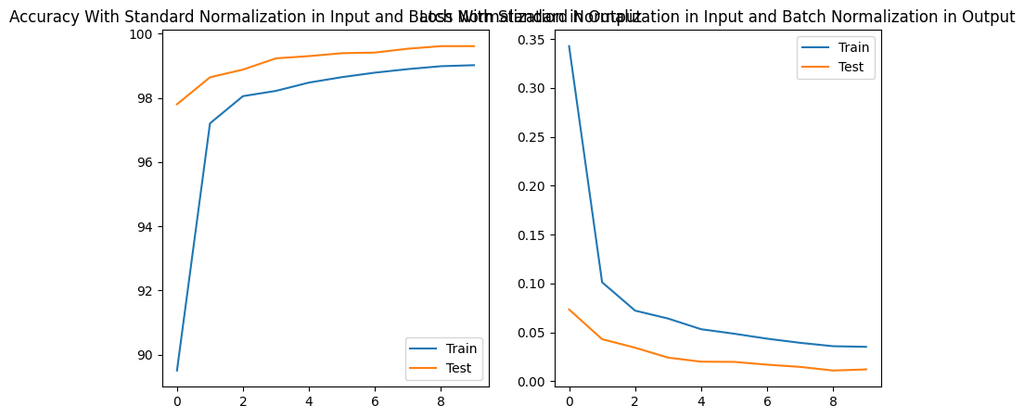

[output not shown]

[output cut: 9 more lines]

[output not shown]

```python
#Solution 1.5

#Solution 1.2):

import torch
import torch.nn as nn
import torch.optim as optim
import torchvision.datasets as datasets
import torchvision.transforms as transforms
import numpy as np
import matplotlib.pyplot as plt

# Load the MNIST dataset
train_dataset = datasets.MNIST(root='./data', train=True, transform=transforms.Compose([
                                    transforms.ToTensor(),
                                    transforms.Normalize((0.5,), (0.5,))
                                ]), download=True)
test_dataset = datasets.MNIST(root='./data', train=False, transform=transforms.Compose([
                                    transforms.ToTensor(),
                                    transforms.Normalize((0.5,), (0.5,))
                                ]), download=True)

# Define the data loaders
batch_size = 64
train_loader = torch.utils.data.DataLoader(train_dataset, batch_size=batch_size, shuffle=True)
test_loader = torch.utils.data.DataLoader(test_dataset, batch_size=batch_size, shuffle=False)

# Define the LeNet-5 model with batch normalization for all layers
class LeNet5BN(nn.Module):
    def __init__(self, num_classes=10):
        super(LeNet5BN, self).__init__()
        self.conv1 = nn.Conv2d(1, 6, kernel_size=5, stride=1)
        self.bn1 = nn.BatchNorm2d(6)
        self.conv2 = nn.Conv2d(6, 16, kernel_size=5, stride=1)
        self.bn2 = nn.BatchNorm2d(16)
        self.fc1 = nn.Linear(16*4*4, 120)
        self.bn3 = nn.BatchNorm1d(120)
        self.fc2 = nn.Linear(120, 84)
        self.bn4 = nn.BatchNorm1d(84)
        self.fc3 = nn.Linear(84, num_classes)
        self.dropout = nn.Dropout(p=0.5)

    def forward(self, x):
        x = self.conv1(x)
        x = F.relu(self.bn1(x))
        x = F.max_pool2d(x, kernel_size=2, stride=2)
        x = self.conv2(x)
        x = F.relu(self.bn2(x))
        x = F.max_pool2d(x, kernel_size=2, stride=2)
        x = x.view(-1, 16*4*4)
        x = F.relu(self.bn3(self.fc1(x)))
        x = F.relu(self.bn4(self.fc2(x)))
        x = self.dropout(x)
        x = self.fc3(x)
        return x

# Initialize the model
model = LeNet5()

# Define the loss function and optimizer
criterion = nn.CrossEntropyLoss()
optimizer = optim.Adam(model.parameters(), lr=0.001)

# Define the batch size and number of epochs
batch_size = 64
n_epochs = 10

# Create data loaders for the train and test datasets
train_loader = torch.utils.data.DataLoader(train_dataset, batch_size=batch_size, shuffle=True)
test_loader = torch.utils.data.DataLoader(test_dataset, batch_size=batch_size, shuffle=False)

# Train the model
train_loss_bn = []
train_acc_bn = []
test_loss_bn = []
test_acc_bn = []

for epoch in range(n_epochs):
    model.train()
    train_loss = 0.0
    train_total = 0
    train_correct = 0
    for i, (inputs, labels) in enumerate(train_loader):
        optimizer.zero_grad()
        outputs = model(inputs)
        loss = criterion(outputs, labels)
        loss.backward()
        optimizer.step()
        train_loss += loss.item() * inputs.size(0)
        _, predicted = torch.max(outputs.data, 1)
        train_total += labels.size(0)
        train_correct += (predicted == labels).sum().item()

        # Print training statistics
        if (i+1) % 100 == 0:
            print('Epoch [{}/{}], Step [{}/{}], Loss: {:.4f}'.format(epoch+1, n_epochs, i+1, len(train_loader), loss.item()))

    train_loss /= len(train_loader.dataset)
    train_acc = 100 * train_correct / train_total
    train_loss_bn.append(train_loss)
    train_acc_bn.append(train_acc)

    model.eval()
    test_loss = 0.0
    test_total = 0
    test_correct = 0
    for i, (inputs, labels) in enumerate(test_loader):
        optimizer.zero_grad()
        outputs = model(inputs)
        loss = criterion(outputs, labels)
        loss.backward()
        optimizer.step()
        test_loss += loss.item() * inputs.size(0)
        _, predicted = torch.max(outputs.data, 1)
        test_total += labels.size(0)
        test_correct += (predicted == labels).sum().item()

    test_loss /= len(test_loader.dataset)
    test_acc = 100 * test_correct / test_total
    test_loss_bn.append(test_loss)
    test_acc_bn.append(test_acc)

    print('Epoch [{}/{}], Train Loss: {:.4f}, Train Acc: {:.2f}, Test Loss: {:.4f}, Test Acc: {:.2f}'.format(epoch+1, n_epochs, train_loss, train_acc, test_loss, test_acc))

plt.figure(figsize=(10, 5))
plt.subplot(1, 2, 1)
plt.plot(train_acc_bn, label='Train')
plt.plot(test_acc_bn, label='Test')
plt.title('Accuracy With Standard Normalization in Input and Batch Normalization in Output')
plt.legend()
plt.subplot(1, 2, 2)
plt.plot(train_loss_bn, label='Train')
plt.plot(test_loss_bn, label='Test')
plt.title('Loss With Standard Normalization in Input and Batch Normalization in Output')
plt.legend()
plt.show()
```